# General Assembly Data Science Immersion Program

# Safe to Eat or Deadly Poisonous?

# Executive Summary

General Assembly is a pioneer in education and career transformation, specializing in today’s most in-demand skills. They are a leading source for training, staffing, and career transitions, fostering a flourishing community of professionals pursuing careers they love.

One of General Assembly's offerings is a Data Science Immersions program. It is an intensive 12-week program which focuses on hands-on experience in the various people, business and technical aspects of the field of Data Science. Participants in the program are required to produce a Capstone Project which highlights the Data Science skills they acquired.

This technical report documents my Capstone Project.

## Problem Statement

This problem is taken from the Kaggle Data Science Competition website. In 2010, Kaggle was founded as a platform for predictive modelling and analytics competitions on which companies and researchers post their data and statisticians and data miners from all over the world compete to produce the best models.

I selected the "Mushroom Classification - Save to Eat of Deadly Poisonous" competition for a couple of reasons. First, the competition supplied a very comprehensive dataset for analysis. Secondly, I have been an avid amateur mycologist for 30 years with a primary focus of putting wild mushrooms on my table. This project offered me an opportunity to bring my own a priori knowledge to the problem while, at the same time, providing a mechanism for me to broaden my knowledge and understanding of the discipline. My motivation for this is purely from a survival perspective as illustrated by the following quote...

*There are old mushroom hunters and bold mushroom hunters, but very few old, bold mushroom hunters!*

There are tales of whole families found dead around thier dinner tables with mushrooms as part of their last meal!

The following Context and Content sections are taken directly from the Kaggle website.

### Context

Although this dataset was originally contributed to the UCI Machine Learning repository nearly 30 years ago, mushroom hunting (otherwise known as "shrooming") is enjoying new peaks in popularity. Learn which features spell certain death and which are most palatable in this dataset of mushroom characteristics. And how certain can your model be?

### Content

This dataset includes descriptions of hypothetical samples corresponding to 23 species of gilled mushrooms in the Agaricus and Lepiota Family Mushroom drawn from The Audubon Society Field Guide to North American Mushrooms (1981). Each species is identified as definitely edible, definitely poisonous, or of unknown edibility and not recommended. This latter class was combined with the poisonous one. The Guide clearly states that there is no simple rule for determining the edibility of a mushroom; no rule like "leaflets three, let it be'' for Poisonous Oak and Ivy.

## Goal

The initial goal of this project was to develop a model that provided a very high probability of classifying mushroom as with Edible or Poisonous given the supplied dataset. Given information supplied with the dataset and my own a priori knowledge of the subject, my initial modeling proved very successful. Given that I chose to run the models over a number of classifying modeling techniques to ascertain which worked best given the nature of the supplied data. The benefits are two-fold; it afforded me the ability to pick the best model for my analysis and it helped exercise and solidify my understanding of the various modeling techniques.

# Identification of outliers

This is a classification problem with a well defined dataset that is entirely categorical in nature. As such, it inherently does not suffer from outliers. However, a close cousin to outliers in classification problems is *imbalanced classes*. Imbalanced classes in this context means that the training classifiers are skewed in one direction or another. An example in a binary classification system such as is the case with this mushroom classification problem would be that the training set would have 90% of the mushroom classed as, let's say, poisonous. This would severly skew our confidence in the model.

The dataset presented for this case contains 8124 samples; 3916 of which are identified as poisonous. This represents 48%-52% split between poisonous and edible samples raising no imbalanced classes issues.

# Data Description

Sources: (a) Mushroom records drawn from The Audubon Society Field Guide to North American Mushrooms (1981). G. H. Lincoff (Pres.), New York: Alfred A. Knopf (b) Donor: Jeff Schlimmer (Jeffrey.Schlimmer@a.gp.cs.cmu.edu) (c) Date: 27 April 1987

Relevant Information: This data set includes descriptions of hypothetical samples corresponding to 23 species of gilled mushrooms in the Agaricus and Lepiota Family (pp. 500-525). Each species is identified as definitely edible, definitely poisonous, or of unknown edibility and not recommended. This latter class was combined with the poisonous one. The Guide clearly states that there is no simple rule for determining the edibility of a mushroom; no rule like "leaflets three, let it be" for Poisonous Oak and Ivy.

Number of Instances: 8124

Number of Attributes: 22 (all nominally valued)

Logical rules for the mushroom data sets.

```
Logical rules given below seem to be the simplest possible for the
mushroom dataset and therefore should be treated as benchmark results.

Disjunctive rules for poisonous mushrooms, from most general
to most specific:

P_1) odor=NOT(almond.OR.anise.OR.none)
     120 poisonous cases missed, 98.52% accu

P_2) spore-print-color=green
     48 cases missed, 99.41% accuracy

P_3) odor=none.AND.stalk-surface-below-ring=scaly.AND.
          (stalk-color-above-ring=NOT.brown)
     8 cases missed, 99.90% accuracy

P_4) habitat=leaves.AND.cap-color=white
         100% accuracy

Rule P_4) may also be

P_4') population=clustered.AND.cap_color=white

These rule involve 6 attributes (out of 22). Rules for edible
mushrooms are obtained as negation of the rules given above, for
example the rule:

odor=(almond.OR.anise.OR.none).AND.spore-print-color=NOT.green
gives 48 errors, or 99.41% accuracy on the whole dataset.

Several slightly more complex variations on these rules exist,
involving other attributes, such as gill_size, gill_spacing,
stalk_surface_above_ring, but the rules given above are the simplest
we have found.
```

Attribute Information: (classes: edible=e, poisonous=p)

```
 1. cap-shape:                bell=b,conical=c,convex=x,flat=f,
                              knobbed=k,sunken=s
 2. cap-surface:              fibrous=f,grooves=g,scaly=y,smooth=s
 3. cap-color:                brown=n,buff=b,cinnamon=c,gray=g,green=r,
                              pink=p,purple=u,red=e,white=w,yellow=y
 4. bruises?:                 bruises=t,no=f
 5. odor:                     almond=a,anise=l,creosote=c,fishy=y,foul=f,
                              musty=m,none=n,pungent=p,spicy=s
 6. gill-attachment:          attached=a,descending=d,free=f,notched=n
 7. gill-spacing:             close=c,crowded=w,distant=d
 8. gill-size:                broad=b,narrow=n
 9. gill-color:               black=k,brown=n,buff=b,chocolate=h,gray=g,
                              green=r,orange=o,pink=p,purple=u,red=e,
                              white=w,yellow=y
10. stalk-shape:              enlarging=e,tapering=t
11. stalk-root:               bulbous=b,club=c,cup=u,equal=e,
                              rhizomorphs=z,rooted=r,missing=?
12. stalk-surface-above-ring: fibrous=f,scaly=y,silky=k,smooth=s
13. stalk-surface-below-ring: fibrous=f,scaly=y,silky=k,smooth=s
14. stalk-color-above-ring:   brown=n,buff=b,cinnamon=c,gray=g,orange=o,
                              pink=p,red=e,white=w,yellow=y
15. stalk-color-below-ring:   brown=n,buff=b,cinnamon=c,gray=g,orange=o,
                              pink=p,red=e,white=w,yellow=y
16. veil-type:                partial=p,universal=u
17. veil-color:               brown=n,orange=o,white=w,yellow=y
18. ring-number:              none=n,one=o,two=t
19. ring-type:                cobwebby=c,evanescent=e,flaring=f,large=l,
                              none=n,pendant=p,sheathing=s,zone=z
20. spore-print-color:        black=k,brown=n,buff=b,chocolate=h,green=r,
                              orange=o,purple=u,white=w,yellow=y
21. population:               abundant=a,clustered=c,numerous=n,
                              scattered=s,several=v,solitary=y
22. habitat:                  grasses=g,leaves=l,meadows=m,paths=p,
                              urban=u,waste=w,woods=d
```

## How the data was used in this project

- shrooms The shrooms datasets are an exact duplicate of the original dataset which are then processed. The columns (attributes) remained the same but the data was converted to categorical integers; i.e., in the description above, the ring-number's values were converted from n, o and t to 0, 1 and 2. Two version of this shrooms dataset were fed to the models:
  - shrooms This is the dataset as described above with all of the attributes. This is a a baseline to start with.
  - shrooms with reduced attributes

    In the data description above you will notice a section titled: Logical rules for the mushroom data sets. The rules detail 4 or 5 rules that look at specific occurances of attribute/value pairs that are very good predictors of whether a mushroom is poisonous or edible. A collection of those attribures were selected from the original dataset and the rest were dropped. Those attribures are...

    ```
      *  "odor"
      *  "spore-print-color"
      *  "stalk-surface-above-ring"
      *  "stalk-color-above-ring"
      *  "habitat"
      *  "population"
      *  "cap-color"
    ```

  - shrooms_dummy

    To further refine our findings, the shrooms data was converted into a 'dummy categories' dataset; that is, each attribute/value combination was given a unique column in our dataset and a value of 1 or 0 (present or not). Given this information we can see if model performance was affected by attribute/value combinations or just by the attributes themselves.

```
*  shrooms_dummy with reduced attribute/value combinations

    Given the 'rules' information above, only attribute/value combinations contained in the rules are included in this version of the data that is supplied to the models. These attribute/value combinations are as follows:
    *  'cap-color_w'
    *  'odor_a'
    *  'odor_l'
    *  'odor_n'
    *  'stalk-surface-below-ring_y'
    *  'stalk-color-above-ring_n'
    *  'spore-print-color_r'
    *  'population_c'
    *  'habitat_l'
```

# Model Selection and Implementation

## Initial Approach

While research appropriate models for use in this binary classification problem I stumbled upon the following graphic at StackOverflow.com...

[figure not shown]

This led me to try 'Linear SVC' and 'K Neighbors' classifiers. Both of these models gave me very strong positive results, but while researching evaluation techniques I found a technique that rotated over a number of classifier models.

## Final Approach

Given the technique I found for iterating over a number of classifier models, some of which I was not familiar with, I decided to apply each of the datasets I prepared (see above) to each of the models I found. Those models are...

```
*  "Nearest Neighbors"
*  "Linear SVM"
*  "RBF SVM"
*  "Gaussian Process
*  "Decision Tree"
*  "Random Forest"
*  "Neural Net"
*  "AdaBoost"
*  "Naive Bayes"
*  "QDA"
```

# Visualizations & Statistical Analysis

Here are a couple of visualizations from the Nearest Neighbors model. As you can see that with an Accuracy Score of 1.0 and a perfect Confusion Matrix, the model is predicting with 100% accuracy.

[output not shown]

[figure not shown]

# Interpretation of Findings & Relation to Goals/Success Metrics

As can be seen from the visualizations above, the problem of classification can be solved with the Nearest Neighbor approach. This is true across a number of the models and datasets. Of special interest is that the model perform at this level of precision with the "shrooms_dummy with reduced attribute/value combinations" dataset with only 9 attributes in the model. This reinforces the machine learning truism that feature reduction is a very important aspect of Data Science.

# Stakeholder Recommendations & Next Steps

### Stakeholders & Whoever may use this model

Any good schroomer will tell you to never trust one source of information when considering eating a mushroom that you collect in the wild. This model may get you into the ballpark, but it is no substiture for classifying a mushroom down to not only a Poisonous/Edible category, but down to the exact species you are looking at. Like anything else in nature, there are variations on what you might see; color, size, etc. I recommend the most current version of The Audubon Society Field Guide to North American Mushrooms for classifying your mushroom. There is an identificaiton section in the back of the book that has you first take a spore print, and then with the color in hand, identify a few features; habitat, veil type, geographical region, etc. Once you complete this process, you are directed to a textural description of the mushroom in question where you can further refine your classification. In this description it will tell you the edibility of a mushroom; poisonous, choice, good, bad, unknown. Just as important, it will tell you if there are any close look-alikes which you should also read up on. You are also then directed to vary beautifly presented photographs of the mushrooms and look-alikes. The photographs should be the last thing you consider.

Once you think you have identified the mushroom and decided that it may find its way to your table, take the following precautions:

- Only eat a small portion of the mushroom on your first try. Even if it is not poisonous, some people have alergies to different mushrooms, so beware. If you have no adverse affects, try some more the next day and keep increasing your consumption until you are confident.
- Whenever you prepare and eat mushrooms (never eat wild mushrooms raw), alway keep a few samples in the refrigerator in case you get sick. If you do get sick, bring the sample to the emergency room with you. Different poisonous mushroom affect the body in different ways (nervous system, gastral, etc.) and there is no one way of treating the poison. Hospital staff can analyse an actual mushroom much better than a description. I started shrooming while living in France where all pharmacists are trained in mushroom classificaiton.
- Alcohol consumption is not recommended while eating wild mushrooms.

REMEMBER - *There are old mushroom hunters, and bold mushroom hunters, but very few old bold mushroom hunters!*

### Next Step Recommendations

1. Create a front end to this program which, at run time, will allow the user to first pick a model to run, and once selected, ask the user to select parameter/value pairs to run. Perhaps this could be in the form of an interactive matrix which the user could select models/parameters/values and the output would be in a form for easy comparison.
2. Geographical region that a mushroom is native to is a very powerful attribute for identifying a particular mushroom. It would be very interesting to have that data added to see if it would be helpful in identifying a mushroom's edibility.
3. The rules provided with the dataset provide a very powerful mechanism for classifying the edibility of a mushroom. I spent a decade of my earlier career as a Knowledge Engineer building rule-based expert systems. From what I have learned in the execution of this project I believe that an expert systems approach would be very helpful in identifying a specific mushroom, and hence its edibility. I believe that a small rule set could be constructed to make a very accurate identification (see cautions above) and specific mushroom data could be added to expert systems working memory (database) as one collected mushrooms in thier local. Just a thought to think!

### Potential Productization

```
I believe that this application has the potential to be adapted to a hybrid application for deployment on a mobile device to aid shroomers in classification in the field.

As described in point 3. above, I believe an expert system could be developed to help identify a mushroom to its exact type to a high degree of probability. I believe that a trained model could always be employed at classification time to act as a double check on the edibility of the mushroom. I envision this as a user enhanced application where the human idenfication of a mushroom in the field could be inputted and stored in the expert system's working memory, making the system more robust with each entry. Optionally, the data could be allowed to be uploaded and shared by other users, increasing the robustness at much higher rates, at least initially. Additionally, with the user's permission, GPS data could also be automatically attached to the stored data at different levels of granularity; exact location for use by the person inputting the data, region or county for sharing with other users (shroomers tend to be a secretive bunch when it comes to their hunting grounds!
```

# Source Code

An attempt has been made to make the Python 3 code (below) self documenting. It needs some cleaning up at the time of this writing but will be improved upon after the visualization routines are complete.

#### The following block is used to import all Python libraries used in this model

```python
import numpy as np
import pandas as pd
import matplotlib as mpl
import seaborn as sns
import random

from matplotlib import pyplot as plt
from matplotlib.colors import ListedColormap
from sklearn.model_selection import train_test_split
from sklearn.model_selection import learning_curve
from sklearn.model_selection import ShuffleSplit
from sklearn.preprocessing import StandardScaler
from sklearn.datasets import make_moons, make_circles, make_classification
from sklearn.neural_network import MLPClassifier
from sklearn.neighbors import KNeighborsClassifier
from sklearn.gaussian_process import GaussianProcessClassifier
from sklearn.gaussian_process.kernels import RBF
from sklearn.tree import DecisionTreeClassifier
from sklearn.ensemble import RandomForestClassifier, AdaBoostClassifier
from sklearn.naive_bayes import GaussianNB
from sklearn.discriminant_analysis import QuadraticDiscriminantAnalysis
from sklearn.metrics import confusion_matrix,  accuracy_score, roc_auc_score
from sklearn.metrics import roc_curve, auc
from matplotlib import pyplot as plt
from sklearn.svm import SVC
from sklearn.cross_validation import cross_val_score
from sklearn.neighbors import KNeighborsClassifier
from sklearn.preprocessing import StandardScaler
from sklearn.datasets import load_digits
from sklearn.model_selection import learning_curve
from sklearn.model_selection import ShuffleSplit

%matplotlib inline
```

#### First let's load in the csv formatted dataset into a pandas dataframe named - original

This 'original' dataframe will not be modified throughout this project and preserved for future analysis if needed in the spirit of "chain of custody". The mushrooms.csv dataset was obtained from the Kaggle.com machine learning competition website.

```python
original = pd.read_csv("mushrooms.csv") #original will be kept for historical purposes
```

#### Next the 'original' dataset will be split into the data and the target components

```python
original_X = original.drop('class', axis=1)
original_y = original['class']

original_X.shape, original_y.shape #ensure that the data and test are the same length
```

```
((8124, 22), (8124,))
```

#### Time to take a look at the data

```python
original_X.head()
```

|  | cap-shape | cap-surface | cap-color | bruises | odor | gill-attachment | gill-spacing | gill-size | gill-color | stalk-shape | ... | stalk-surface-below-ring | stalk-color-above-ring | stalk-color-below-ring | veil-type | veil-color | ring-number | ring-type | spore-print-color | population | habitat |
| --- | --- | --- | --- | --- | --- | --- | --- | --- | --- | --- | --- | --- | --- | --- | --- | --- | --- | --- | --- | --- | --- |
| 0 | x | s | n | t | p | f | c | n | k | e | ... | s | w | w | p | w | o | p | k | s | u |
| 1 | x | s | y | t | a | f | c | b | k | e | ... | s | w | w | p | w | o | p | n | n | g |
| 2 | b | s | w | t | l | f | c | b | n | e | ... | s | w | w | p | w | o | p | n | n | m |
| 3 | x | y | w | t | p | f | c | n | n | e | ... | s | w | w | p | w | o | p | k | s | u |
| 4 | x | s | g | f | n | f | w | b | k | t | ... | s | w | w | p | w | o | e | n | a | g |

5 rows × 22 columns

```python
original_y.head()
```

```
0    p
1    e
2    e
3    p
4    e
Name: class, dtype: object
```

Given that the target data is supposed to contain either a p (poisonous) or e (edible) value, let's test to make sure that this is the case.

```python
class_is_good = True
for val in original_y:
    if val != 'p' and val != 'e':
        class_is_good = False
class_is_good
```

```
True
```

#### Now we can start manipulating the data

First let's see if there are any missing data in the data dataframe

```python
original_X.isnull().sum().sum()
```

```
0
```

Similarly, we can look to see if there are any missing data in the target dataframe

```python
original_y.isnull().sum()
```

```
0
```

Let's see if we have an imbalance in the classification y set

```python
p = original_y == 'p'
p.sum()
```

```
3916
```

The data looks complete in both, so now we can convert the string descriptions in the datasets as listed in the "Data Description" section above into integers for use in all of the models. But before we do this, let us copy the 'original' data into the working datasets shrooms_X and shrooms_y to preserve the integrity of the original data.

```python
shrooms = original.copy()
shrooms_X = original_X.copy()
columns = shrooms_X.columns
shrooms_y = original_y.copy()

for col in columns:
    shrooms_X[col] = shrooms_X[col].astype('category') # the next line relies on a category data type
    shrooms_X[col] = shrooms_X[col].cat.codes # converts categorical data to unique integers
    shrooms_X[col] = shrooms_X[col].astype('int') # convert the column to an integer data type for data exploration

shrooms_y = shrooms_y.astype('category') # the next line relies on a category data type
shrooms_y = shrooms_y.cat.codes # converts categorical data to unique integers
shrooms_y = shrooms_y.astype('int') # convert the column to an integer data type for data exploration


# print(shrooms_X.head())
# print(shrooms_y.head()) # both conversions look good!
shrooms_X.describe()
```

|  | cap-shape | cap-surface | cap-color | bruises | odor | gill-attachment | gill-spacing | gill-size | gill-color | stalk-shape | ... | stalk-surface-below-ring | stalk-color-above-ring | stalk-color-below-ring | veil-type | veil-color | ring-number | ring-type | spore-print-color | population | habitat |
| --- | --- | --- | --- | --- | --- | --- | --- | --- | --- | --- | --- | --- | --- | --- | --- | --- | --- | --- | --- | --- | --- |
| count | 8124.000000 | 8124.000000 | 8124.000000 | 8124.000000 | 8124.000000 | 8124.000000 | 8124.000000 | 8124.000000 | 8124.000000 | 8124.000000 | ... | 8124.000000 | 8124.000000 | 8124.000000 | 8124.0 | 8124.000000 | 8124.000000 | 8124.000000 | 8124.000000 | 8124.000000 | 8124.000000 |
| mean | 3.348104 | 1.827671 | 4.504677 | 0.415559 | 4.144756 | 0.974151 | 0.161497 | 0.309207 | 4.810684 | 0.567208 | ... | 1.603644 | 5.816347 | 5.794682 | 0.0 | 1.965534 | 1.069424 | 2.291974 | 3.596750 | 3.644018 | 1.508616 |
| std | 1.604329 | 1.229873 | 2.545821 | 0.492848 | 2.103729 | 0.158695 | 0.368011 | 0.462195 | 3.540359 | 0.495493 | ... | 0.675974 | 1.901747 | 1.907291 | 0.0 | 0.242669 | 0.271064 | 1.801672 | 2.382663 | 1.252082 | 1.719975 |
| min | 0.000000 | 0.000000 | 0.000000 | 0.000000 | 0.000000 | 0.000000 | 0.000000 | 0.000000 | 0.000000 | 0.000000 | ... | 0.000000 | 0.000000 | 0.000000 | 0.0 | 0.000000 | 0.000000 | 0.000000 | 0.000000 | 0.000000 | 0.000000 |
| 25% | 2.000000 | 0.000000 | 3.000000 | 0.000000 | 2.000000 | 1.000000 | 0.000000 | 0.000000 | 2.000000 | 0.000000 | ... | 1.000000 | 6.000000 | 6.000000 | 0.0 | 2.000000 | 1.000000 | 0.000000 | 2.000000 | 3.000000 | 0.000000 |
| 50% | 3.000000 | 2.000000 | 4.000000 | 0.000000 | 5.000000 | 1.000000 | 0.000000 | 0.000000 | 5.000000 | 1.000000 | ... | 2.000000 | 7.000000 | 7.000000 | 0.0 | 2.000000 | 1.000000 | 2.000000 | 3.000000 | 4.000000 | 1.000000 |
| 75% | 5.000000 | 3.000000 | 8.000000 | 1.000000 | 5.000000 | 1.000000 | 0.000000 | 1.000000 | 7.000000 | 1.000000 | ... | 2.000000 | 7.000000 | 7.000000 | 0.0 | 2.000000 | 1.000000 | 4.000000 | 7.000000 | 4.000000 | 2.000000 |
| max | 5.000000 | 3.000000 | 9.000000 | 1.000000 | 8.000000 | 1.000000 | 1.000000 | 1.000000 | 11.000000 | 1.000000 | ... | 3.000000 | 8.000000 | 8.000000 | 0.0 | 3.000000 | 2.000000 | 4.000000 | 8.000000 | 5.000000 | 6.000000 |

8 rows × 22 columns

#### We also need to create a dataset of categorical dummy attributes in order to separate the various attributes of each characteristic from each other. We will run our models on this set of data as well.

```python
shrooms_dummy_X = original_X.copy()
columns = shrooms_dummy_X.columns
#columns = columns.drop('class') # we won't make dummy columns for our target column
for col in columns:
    for data in shrooms_dummy_X[col].unique():
        shrooms_dummy_X[col + "_" + data] = shrooms_dummy_X[col] == data

# we can now drop the original columns
for col in columns:
    shrooms_dummy_X.drop(col, inplace = True, axis = 1)
#shrooms_dummy_X.head()
# Now let's replace all of the bool values (True/False) with integers (1/0)

shrooms_dummy_X = shrooms_dummy_X.astype(int)
shrooms_dummy_X.head()
```

|  | cap-shape_x | cap-shape_b | cap-shape_s | cap-shape_f | cap-shape_k | cap-shape_c | cap-surface_s | cap-surface_y | cap-surface_f | cap-surface_g | ... | population_v | population_y | population_c | habitat_u | habitat_g | habitat_m | habitat_d | habitat_p | habitat_w | habitat_l |
| --- | --- | --- | --- | --- | --- | --- | --- | --- | --- | --- | --- | --- | --- | --- | --- | --- | --- | --- | --- | --- | --- |
| 0 | 1 | 0 | 0 | 0 | 0 | 0 | 1 | 0 | 0 | 0 | ... | 0 | 0 | 0 | 1 | 0 | 0 | 0 | 0 | 0 | 0 |
| 1 | 1 | 0 | 0 | 0 | 0 | 0 | 1 | 0 | 0 | 0 | ... | 0 | 0 | 0 | 0 | 1 | 0 | 0 | 0 | 0 | 0 |
| 2 | 0 | 1 | 0 | 0 | 0 | 0 | 1 | 0 | 0 | 0 | ... | 0 | 0 | 0 | 0 | 0 | 1 | 0 | 0 | 0 | 0 |
| 3 | 1 | 0 | 0 | 0 | 0 | 0 | 0 | 1 | 0 | 0 | ... | 0 | 0 | 0 | 1 | 0 | 0 | 0 | 0 | 0 | 0 |
| 4 | 1 | 0 | 0 | 0 | 0 | 0 | 1 | 0 | 0 | 0 | ... | 0 | 0 | 0 | 0 | 1 | 0 | 0 | 0 | 0 | 0 |

5 rows × 117 columns

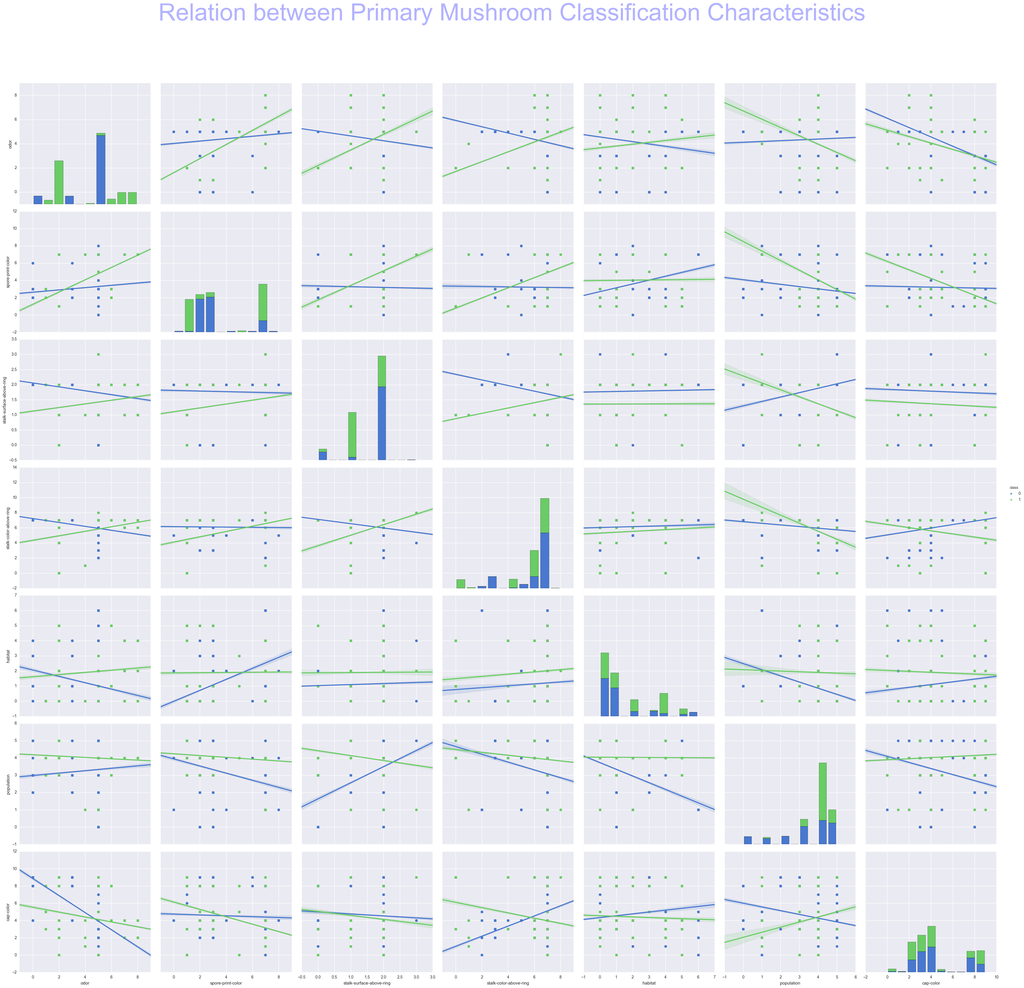

```python
# Create a Pairplot
g = sns.pairplot(shrooms_plot,hue="class",palette="muted",size=5,
    vars=["odor", "spore-print-color", "stalk-surface-above-ring", "stalk-color-above-ring", "habitat", "population", "cap-color" ],kind='reg')

# To change the size of the scatterpoints in graph
g = g.map_offdiag(plt.scatter,  s=35, alpha=0.5)

# remove the top and right line in graph
sns.despine()
# Additional line to adjust some appearance issue
plt.subplots_adjust(top=0.9)

# Set the Title of the graph from here
g.fig.suptitle('Relation between Primary Mushroom Classification Characteristics',
    fontsize=60,color="b",alpha=0.3)
```

```python
datasets = [
            (shrooms_dummy_X,shrooms_y),
            (shrooms_dummy_X[[
                        'cap-color_w',
                        'odor_a',
                        'odor_l',
                        'odor_n',
                        'stalk-surface-below-ring_y',
                        'stalk-color-above-ring_n',
                        'spore-print-color_r',
                        'population_c',
                        'habitat_l']], shrooms_y),
             (shrooms_X, shrooms_y),               # all characteristics
             (shrooms_X[["odor",                    # only important characteristics for rule-based classification
                        "spore-print-color",
                        "stalk-surface-above-ring",
                        "stalk-color-above-ring",
                        "habitat",
                        "population",
                        "cap-color" ]], shrooms_y),
            ]
figure = plt.figure(figsize=(27, 9))

names = [
     "Nearest Neighbors",
     "Linear SVM",
     "RBF SVM",
     "Gaussian Process",
     "Decision Tree",
     "Random Forest",
     "Neural Net",
     "AdaBoost",
     "Naive Bayes",
     "QDA"
    ]

classifiers = [
     KNeighborsClassifier(3, algorithm='auto'),
     SVC(kernel="linear", C=0.025),
     SVC(gamma=2, C=1),
     GaussianProcessClassifier(1.0 * RBF(1.0), warm_start=True),
     DecisionTreeClassifier(max_depth=5),
     RandomForestClassifier(max_depth=5, n_estimators=10, max_features=1),
     MLPClassifier(alpha=1),
     AdaBoostClassifier(),
     GaussianNB(),
     QuadraticDiscriminantAnalysis()
]

results = pd.DataFrame(columns=('dataset', 'classifier', 'model', 'score', 'conmat', 'roc_auc_score', 'false_positive_rate', 'true_positive_rate'))
labels = [1,0]
i = 0 # counter for adding rows to the results dataset

for dataset_count, dataset in enumerate(datasets):

    X, y = dataset
    X = StandardScaler().fit_transform(X)
    X_train, X_test, y_train, y_test = \
            train_test_split(X, y, test_size=.4, random_state=42)


    # iterate over classifiers
    for name, clf in zip(names, classifiers):

        clf.fit(X_train, y_train)
        y_predict = clf.predict(X_test)
        score = accuracy_score(y_test, y_predict)
        con_mat = confusion_matrix(y_test, y_predict, labels)
        roc_auc = roc_auc_score(y_test, y_predict)

        false_positive_rate, true_positive_rate, thresholds = roc_curve(y_test, y_predict)



        results.loc[i] = [dataset_count, name, clf, score, con_mat, roc_auc, false_positive_rate, true_positive_rate]
        i += 1


results

# plt.tight_layout()
# plt.show()
```

[output not shown]

[output not shown]

```python
#        plt.title('Receiver Operating Characteristic')
#         plt.plot(false_positive_rate, true_positive_rate, 'b',
#         label='AUC = %0.2f'% roc_auc)
#         plt.legend(loc='lower right')
#         plt.plot([0,1],[0,1],'r--')
#         plt.xlim([-0.1,1.2])
#         plt.ylim([-0.1,1.2])
#         plt.ylabel('True Positive Rate')
#         plt.xlabel('False Positive Rate')
#         plt.show()
```

```python
# save the results from above
results.to_csv("results.csv")
```

```python
results = pd.read_csv("results.csv")
```

```python
# the plot_learning_curve function will be used as another way to evaluate models



def plot_learning_curve(estimator, title, X, y, ylim=None, cv='y',
                        n_jobs=1, train_sizes=np.linspace(.1, 1.0, 5)):
    """
    Generate a simple plot of the test and training learning curve.

    Parameters
    ----------
    estimator : object type that implements the "fit" and "predict" methods
        An object of that type which is cloned for each validation.

    title : string
        Title for the chart.

    X : array-like, shape (n_samples, n_features)
        Training vector, where n_samples is the number of samples and
        n_features is the number of features.

    y : array-like, shape (n_samples) or (n_samples, n_features), optional
        Target relative to X for classification or regression;
        None for unsupervised learning.

    ylim : tuple, shape (ymin, ymax), optional
        Defines minimum and maximum yvalues plotted.

    cv : int, cross-validation generator or an iterable, optional
        Determines the cross-validation splitting strategy.
        Possible inputs for cv are:
          - None, to use the default 3-fold cross-validation,
          - integer, to specify the number of folds.
          - An object to be used as a cross-validation generator.
          - An iterable yielding train/test splits.

        For integer/None inputs, if ``y`` is binary or multiclass,
        :class:`StratifiedKFold` used. If the estimator is not a classifier
        or if ``y`` is neither binary nor multiclass, :class:`KFold` is used.

        Refer :ref:`User Guide <cross_validation>` for the various
        cross-validators that can be used here.

    n_jobs : integer, optional
        Number of jobs to run in parallel (default 1).
    """
    plt.figure()
    plt.title(title)
    if ylim is not None:
        plt.ylim(*ylim)
    plt.xlabel("Training examples")
    plt.ylabel("Score")
    train_sizes, train_scores, test_scores = learning_curve(
        estimator, X, y, cv=cv, n_jobs=n_jobs, train_sizes=train_sizes)
    train_scores_mean = np.mean(train_scores, axis=1)
    train_scores_std = np.std(train_scores, axis=1)
    test_scores_mean = np.mean(test_scores, axis=1)
    test_scores_std = np.std(test_scores, axis=1)
    plt.grid()

    plt.fill_between(train_sizes, train_scores_mean - train_scores_std,
                     train_scores_mean + train_scores_std, alpha=0.1,
                     color="r")
    plt.fill_between(train_sizes, test_scores_mean - test_scores_std,
                     test_scores_mean + test_scores_std, alpha=0.1, color="g")
    plt.plot(train_sizes, train_scores_mean, 'o-', color="r",
             label="Training score")
    plt.plot(train_sizes, test_scores_mean, 'o-', color="g",
             label="Cross-validation score")

    plt.legend(loc="best")
    return plt
```

### Below this point is work in progress...

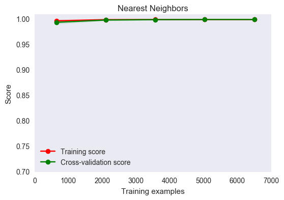

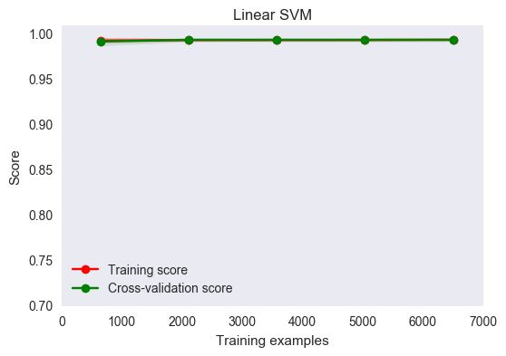

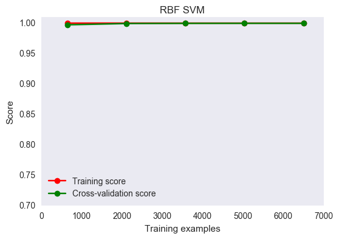

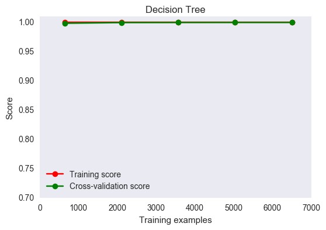

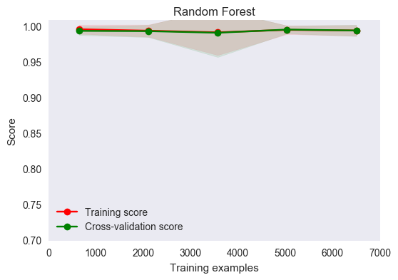

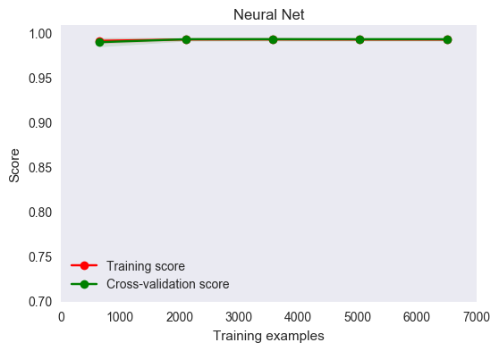

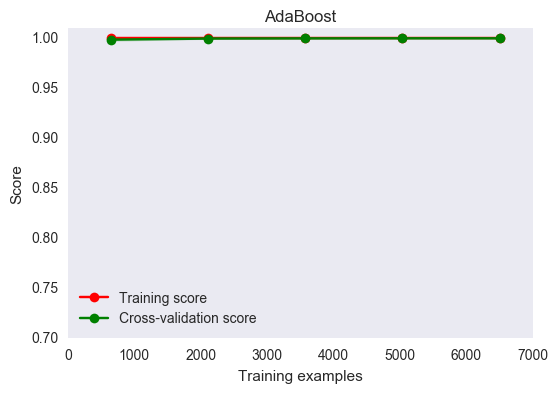

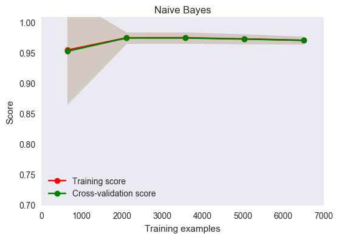

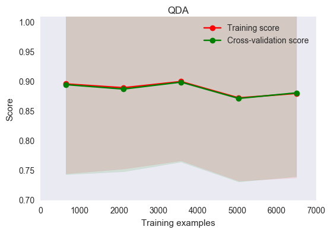

```python
X, y =             shrooms_dummy_X[[
                        'cap-color_w',
                        'odor_a',
                        'odor_l',
                        'odor_n',
                        'stalk-surface-below-ring_y',
                        'stalk-color-above-ring_n',
                        'spore-print-color_r',
                        'population_c',
                        'habitat_l']], shrooms_y
classifiers = [
     KNeighborsClassifier(3, algorithm='auto'),
     SVC(kernel="linear", C=0.3, probability=True,),
       SVC(gamma=2, C=1),
#      GaussianProcessClassifier(1.0 * RBF(1.0), warm_start=True),
      DecisionTreeClassifier(max_depth=5),
      RandomForestClassifier(max_depth=5, n_estimators=10, max_features=1),
      MLPClassifier(alpha=1),
      AdaBoostClassifier(),
      GaussianNB(),
      QuadraticDiscriminantAnalysis()
]

names = [
        "Nearest Neighbors",
        "Linear SVM",
        "RBF SVM",
#        "Gaussian Process",
        "Decision Tree",
        "Random Forest",
        "Neural Net",
        "AdaBoost",
        "Naive Bayes",
        "QDA"
    ]

# iterate over classifiers
for name, clf in zip(names, classifiers):
    title = name
    # Cross validation with 100 iterations to get smoother mean test and train
    # score curves, each time with 20% data randomly selected as a validation set.
    cv = ShuffleSplit(n_splits=100, test_size=0.2, random_state=0)

    estimator = clf
    plot_learning_curve(estimator, title, X, y, ylim=(0.7, 1.01), cv=cv, n_jobs=4)
    plt.show()

# title = "Learning Curves (SVM, RBF kernel, $\gamma=0.001$)"
# # SVC is more expensive so we do a lower number of CV iterations:
# cv = ShuffleSplit(n_splits=10, test_size=0.2, random_state=0)
# estimator = SVC(gamma=0.001)
# plot_learning_curve(estimator, title, X, y, (0.7, 1.01), cv=cv, n_jobs=4)
# labels = ['business', 'health']
# cm = confusion_matrix(y_test, pred, labels)
# print(cm)
# fig = plt.figure()
# ax = fig.add_subplot(111)
# cax = ax.matshow(cm)
# pl.title('Confusion matrix of the classifier')
# fig.colorbar(cax)
# ax.set_xticklabels([''] + labels)
# ax.set_yticklabels([''] + labels)
# pl.xlabel('Predicted')
# pl.ylabel('True')
# pl.show()
```

Some resources for visualization techniques...

http://scikit-learn.org/stable/modules/generated/sklearn.svm.LinearSVC.html http://scikit-learn.org/stable/auto_examples/svm/plot_svm_nonlinear.html http://scikit-learn.org/stable/modules/generated/sklearn.metrics.confusion_matrix.html http://scikit-learn.org/stable/auto_examples/classification/plot_classification_probability.html#sphx-glr-auto-examples-classification-plot-classification-probability-py http://scikit-learn.org/stable/auto_examples/svm/plot_rbf_parameters.html

https://jmetzen.github.io/2015-01-29/ml_advice.html

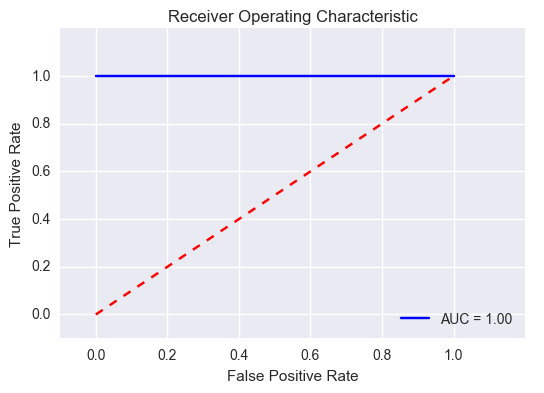

```python
actual = [1,1,1,0,0,0]
predictions = [0.9,0.9,0.9,0.1,0.1,0.1]

false_positive_rate, true_positive_rate, thresholds = roc_curve(actual, predictions)
roc_auc = auc(false_positive_rate, true_positive_rate)

plt.title('Receiver Operating Characteristic')
plt.plot([0.0, 1.0], [1.0,1.0], 'b',
label='AUC = %0.2f'% roc_auc)
plt.legend(loc='lower right')
plt.plot([0,1],[0,1],'r--')
plt.xlim([-0.1,1.2])
plt.ylim([-0.1,1.2])
plt.ylabel('True Positive Rate')
plt.xlabel('False Positive Rate')
plt.show()
```

```python
results['dataset'] = results['dataset'].astype(int)
i = 0
for dataset in results['dataset'].unique():

#    print("Dataset {}".format(dataset))
#    print(results.loc[dataset]['false_positive_rate'], results.loc[dataset]['true_positive_rate'])
    while dataset == results.loc[dataset]['dataset'] and i < 32:
        print("Dataset {} with Classifier {} Accuracy Score = {}".format(results.loc[i]['dataset'], results.loc[i]['classifier'], results.loc[i]['score'] ) )
#        print("Confusion Matrix")
        from mlxtend.plotting import plot_confusion_matrix
        import matplotlib.pyplot as plt
        import numpy as np

        binary = np.array([[1572, 0],
                           [0, 1678]])
#        print(results.loc[i]['conmat'])
        fig, ax = plot_confusion_matrix(conf_mat=binary)
#        plt.show()
        i += 1





#     ax1 = fig.add_subplot(111)
#     ax1.title.set_text('Receiver Operating Characteristic')
#     ax1.plot(results.loc[0]['false_positive_rate'], results.loc[0]['true_positive_rate'], 'b', label=("Poisonous", "Edible"))
#     ax1.legend(loc='lower right')
#     ax1.plot([0,1],[0,1],'r--')
#    ax1.xlim([-0.1,1.2])
#    ax1.ylim([-0.1,1.2])
#    ax1.ylabel('True Positive Rate')
#    ax1.xlabel('False Positive Rate')
#    ax1.show()

#     ax2 = fig.add_subplot(212)
#     ax3 = fig.add_subplot(313)
#     ax4 = fig.add_subplot(414)
#     ax5 = fig.add_subplot(515)
#     ax6 = fig.add_subplot(616)
#     ax7 = fig.add_subplot(717)
#     ax8 = fig.add_subplot(818)
#     ax9 = fig.add_subplot(919)
#    plt.show
#    plt.clf
```

```
Dataset 0 with Classifier Nearest Neighbors Accuracy Score = 1.0
Dataset 0 with Classifier Linear SVM Accuracy Score = 0.5163076923076924
Dataset 0 with Classifier RBF SVM Accuracy Score = 0.9996923076923075
Dataset 0 with Classifier Gaussian Process Accuracy Score = 0.9412307692307692
Dataset 0 with Classifier Decision Tree Accuracy Score = 1.0
Dataset 0 with Classifier Random Forest Accuracy Score = 1.0
Dataset 0 with Classifier Neural Net Accuracy Score = 0.9636923076923076
Dataset 0 with Classifier AdaBoost Accuracy Score = 1.0
Dataset 1 with Classifier Nearest Neighbors Accuracy Score = 1.0
Dataset 1 with Classifier Linear SVM Accuracy Score = 1.0
Dataset 1 with Classifier RBF SVM Accuracy Score = 1.0
Dataset 1 with Classifier Gaussian Process Accuracy Score = 1.0
Dataset 1 with Classifier Decision Tree Accuracy Score = 0.9990769230769232
Dataset 1 with Classifier Random Forest Accuracy Score = 1.0
Dataset 1 with Classifier Neural Net Accuracy Score = 0.972
Dataset 1 with Classifier AdaBoost Accuracy Score = 0.9935384615384616
Dataset 2 with Classifier Nearest Neighbors Accuracy Score = 1.0
Dataset 2 with Classifier Linear SVM Accuracy Score = 0.5163076923076924
Dataset 2 with Classifier RBF SVM Accuracy Score = 0.9809230769230768
Dataset 2 with Classifier Gaussian Process Accuracy Score = 0.9735384615384616
Dataset 2 with Classifier Decision Tree Accuracy Score = 0.9996923076923075
Dataset 2 with Classifier Random Forest Accuracy Score = 1.0
```

```
C:\Program Files\Anaconda3\lib\site-packages\matplotlib\pyplot.py:524: RuntimeWarning: More than 20 figures have been opened. Figures created through the pyplot interface (`matplotlib.pyplot.figure`) are retained until explicitly closed and may consume too much memory. (To control this warning, see …
  max_open_warning, RuntimeWarning)
```

```
Dataset 2 with Classifier Neural Net Accuracy Score = 0.930153846153846
Dataset 2 with Classifier AdaBoost Accuracy Score = 0.804923076923077
Dataset 3 with Classifier Nearest Neighbors Accuracy Score = 1.0
Dataset 3 with Classifier Linear SVM Accuracy Score = 1.0
Dataset 3 with Classifier RBF SVM Accuracy Score = 0.9935384615384616
Dataset 3 with Classifier Gaussian Process Accuracy Score = 0.992
Dataset 3 with Classifier Decision Tree Accuracy Score = 0.9683076923076924
Dataset 3 with Classifier Random Forest Accuracy Score = 1.0
Dataset 3 with Classifier Neural Net Accuracy Score = 0.8652307692307692
Dataset 3 with Classifier AdaBoost Accuracy Score = 0.9073846153846152
```

[output not shown]

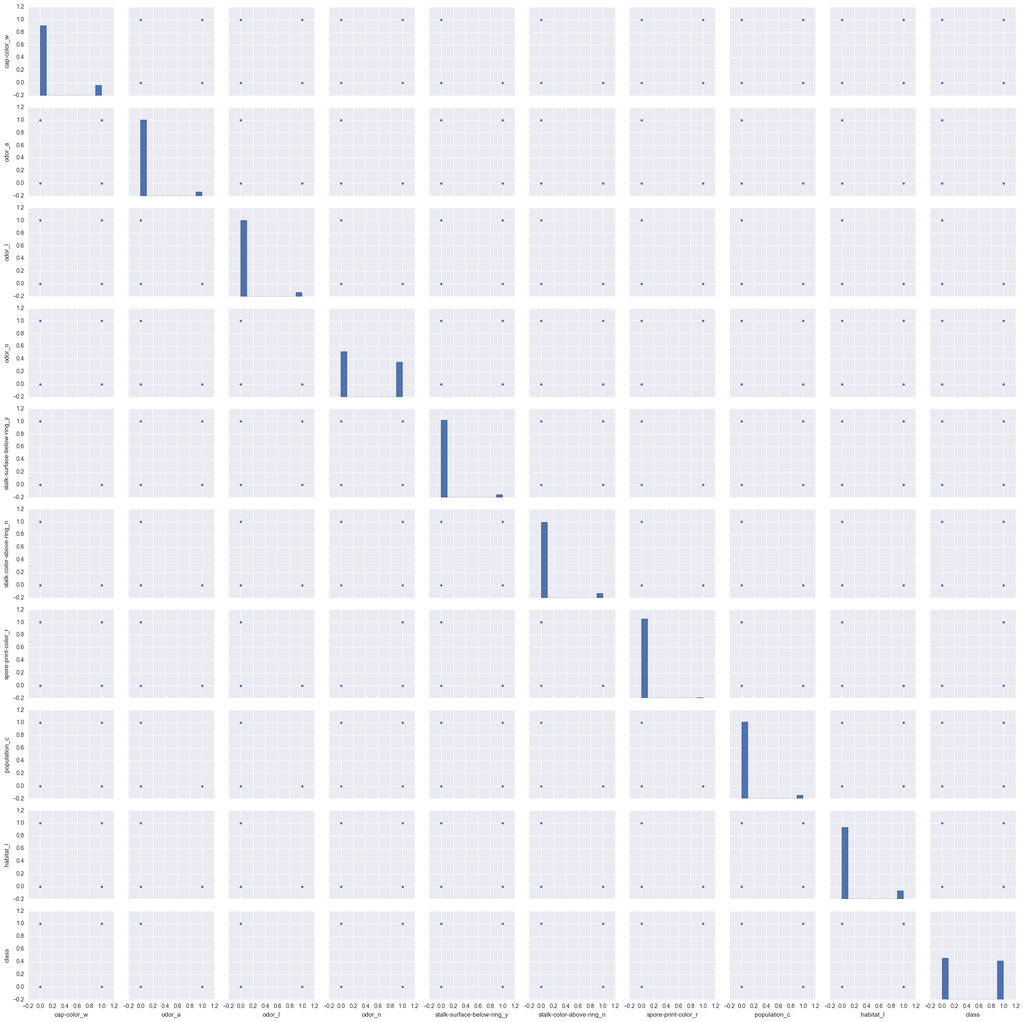

```python
shrooms_plot = shrooms_dummy_X[[
                        'cap-color_w',
                        'odor_a',
                        'odor_l',
                        'odor_n',
                        'stalk-surface-below-ring_y',
                        'stalk-color-above-ring_n',
                        'spore-print-color_r',
                        'population_c',
                        'habitat_l']]

shrooms_plot.loc[:,'class'] = shrooms_y
g = sns.pairplot(shrooms_plot)
```